# TP FINAL: Modelado de Residuos Especiales en la Provincia de Buenos Aires

Juan Pablo Picasso

04/12/2022

# 1) Preparación

### **Se cargan las librerías**

```r
library(dplyr)
library(ggplot2)
library(prophet)
library(lubridate)
library(cowplot)
```

### **Se define el estilo general para los gráficos**

```r
theme <- theme(text = element_text(size=10),
               plot.title = element_text(size = 12, face = "bold.italic", hjust = 0.5),
               axis.title.x = element_text(size = 10, face="bold", colour='black'),
               axis.title.y = element_text(size = 10, face="bold"),
               panel.border = element_blank(),
               panel.grid.major = element_blank(),
               panel.grid.minor = element_blank(),
               legend.title = element_text(face="bold"))
```

### **Se cargan los datos**

La variable correspondiente a la “fecha de retiro” se carga en el formato “date” con año, mes y día (YYYY-MM-DD).

```r
rrpp <- read.csv('TP2/manifiestos_rree.csv')%>%
  mutate(fecha_retiro = ymd(fecha_retiro))
```

# 2) Análisis exploratorio

Presentación resumida de las variables

```r
glimpse(rrpp)
```

```
## Rows: 395,325
## Columns: 36
## $ numero                     <int> 3000312, 3000313, 3000316, 3000321, 3000325…
## $ certificado                <int> 875263, 902328, 856441, 902426, 880034, 878…
## $ cuit_generador             <chr> "30-70759184/2 (Id:11081)", "30-67813830/0 …
## $ razon_social_generador     <chr> "GAS LANUS S.A.", "WAL MART ARGENTINA S.R.L…
## $ domicilio_generador        <chr> "25 DE MAYO Nº : 883 Ruta: : 210 (PAV?N)", …
## $ localidad_generador        <chr> "LANUS", "MORENO", "BAHIA BLANCA", "MARTINE…
## $ cuit_transportista         <chr> "30-71008458/7 (Id:37494)", "30-70845639/6 …
## $ che_transportista          <dbl> 355, 247, 356, 486, 51, 111, 51, 390, 139, …
## $ razon_social_transportista <chr> "LA RUMANA S.R.L.", "FRANCO TRANSPORTES S.R…
## $ domicilio_transportista    <chr> "LOS PINOS Nº : 155", "FLORENCIO SANCHEZ Nº…
## $ localidad_transportista    <chr> "SAN ANTONIO DE PADUA", "LA TABLADA", "BAHI…
## $ destino                    <chr> "Tratador", "Tratador", "Tratador", "Tratad…
## $ che_destino                <dbl> 327, 327, 160, 134, 134, 262, 271, 144, 224…
```

[output cut: 23 more lines]

La base de datos original cuenta con 395325 registros y 36 variables. Cada registro cuenta con un número correspondiente al número de manifiesto. 15 de estas variables refieren a distintos datos de los generadores, transportista y operadores, como nombre de la empresa, CUIT, domicilio y localidad.

```r
vars_numericas <- colnames(rrpp %>% select(where(is.numeric)))
vars_numericas
```

```
## [1] "numero"            "certificado"       "che_transportista"
## [4] "che_destino"       "cantidad_verif_1"  "cantidad_verif_2"
## [7] "cantidad_verif_3"
```

Las variables numéricas son 7. Aparte de la fecha de retiro, el resto de las variables son de tipo categóricas.

```r
length(unique(rrpp$cuit_generador)) #reviso todas las categorías de la variable
```

```
## [1] 21293
```

```r
length(unique(rrpp$localidad_transportista)) #reviso todas las categorías de la variable
```

```
## [1] 113
```

```r
length(unique(rrpp$cuit_transportista)) #reviso todas las categorías de la variable
```

```
## [1] 221
```

```r
length(unique(rrpp$localidad_destino)) #reviso todas las categorías de la variable
```

```
## [1] 45
```

```r
length(unique(rrpp$cuit_destino)) #reviso todas las categorías de la variable
```

```
## [1] 64
```

Las empresas transportistas y las operadoras presentan una menor cantidad y también su ubicación se encuentra más acotada. Algunas de estas empresas se encuentran radicadas en otras provincias (ej. Córdoba y Santa Fe).

Se agrega una columna correspondiente al año en el cual se realizo el retiro y posteriormente se calculan las proporciones de registros para cada año.

```r
rrpp$anio <- year(rrpp$fecha_retiro)
```

Se pretende trabajar con la cantidad total de cada registro.

```r
rrpp$cantidad_total <- rrpp %>% select(contains("cantidad")) %>% rowSums(na.rm=TRUE)
```

Focalizando en las variables que se utilizan en el modelo, se presentan los datos de cantidad de registros (o retiros) y peso de residuos especiales.

```r
#calculo la cantidad absoluta y relativa de registros por año
n_x_anio <- rrpp %>% select(anio, cantidad_total) %>% group_by(anio) %>% summarise(n = n()) %>%
  mutate(freq = n / sum(n))
n_x_anio
```

| anio | n | freq |
| --- | --- | --- |
| 2016 | 46913 | 0.1186694 |
| 2017 | 80342 | 0.2032303 |
| 2018 | 85092 | 0.2152457 |
| 2019 | 88493 | 0.2238487 |
| 2020 | 46048 | 0.1164814 |
| 2021 | 48437 | 0.1225245 |

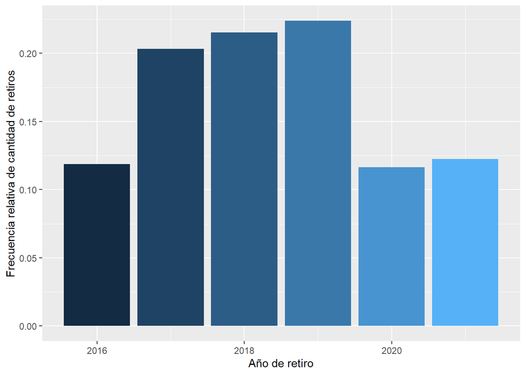

```r
#grafico de frecuencia relativa con la cantidad de retiros por año
ggplot(n_x_anio) +
  geom_bar(aes(x=anio, y=freq, fill=anio), stat="identity", show.legend = FALSE)+
    labs( x='Año de retiro', y='Frecuencia relativa de cantidad de retiros')
```

```r
#calculo la cantidad absoluta y relativa de residuos (kg) por año
cant_x_anio<-rrpp %>% select(anio, cantidad_total) %>% group_by(anio) %>%
  summarise(cantidad_total = sum(cantidad_total)) %>%
  mutate(freq = cantidad_total / sum(cantidad_total))
cant_x_anio
```

| anio | cantidad_total | freq |
| --- | --- | --- |
| 2016 | 205740730 | 0.1012797 |
| 2017 | 368221434 | 0.1812638 |
| 2018 | 418352966 | 0.2059420 |
| 2019 | 513197924 | 0.2526311 |
| 2020 | 255764562 | 0.1259048 |
| 2021 | 270134441 | 0.1329787 |

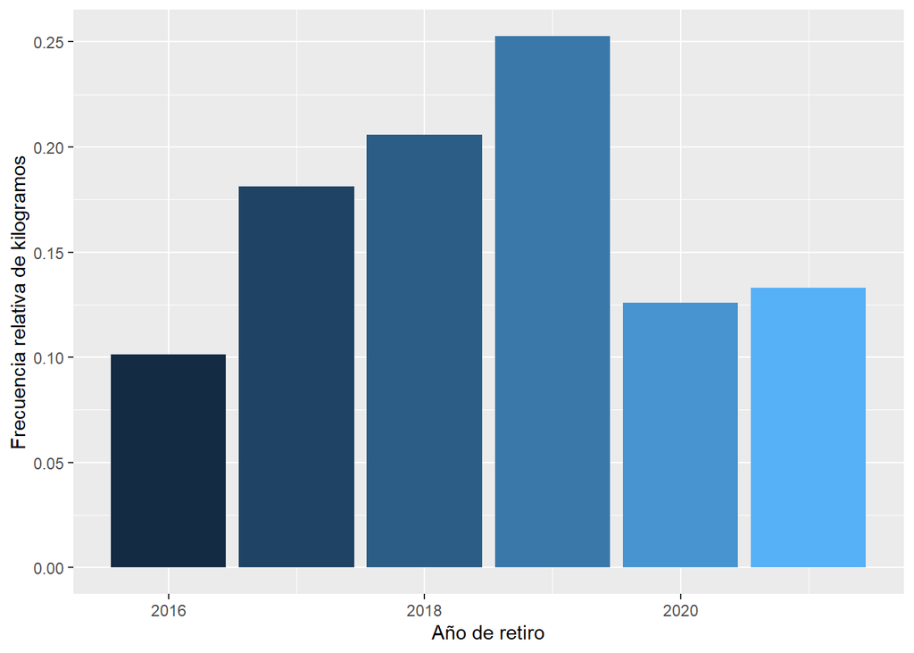

```r
#grafico de frecuencia relativa con las cantidades de residuos (kg) por año
ggplot(cant_x_anio) +
  geom_bar(aes(x=anio, y=freq, fill=anio), stat="identity", show.legend = FALSE)+
    labs( x='Año de retiro', y='Frecuencia relativa de kilogramos')
```

Como se puede observar los años con menor proporcion de registros son 2016, 2020 y 2021. Además, al revisar las cantidades de residuos retirados en cada año, los valores no descienden de las 200.000 toneladas. El año 2019 superó las 500.000 toneladas, representando el cerca del 25% de todo el período.

En cada fecha, se observa una gran cantidad de registros, lo cual podría dificultar la visualización por lo que se decide agruparlos. De esta forma, todos los retiros que se hayan realizado en la misma fecha se suman para tener un valor prácticamente diario.

```r
#se arma un df con las cantidades de residuos totales por día
rrpp_dia<-  rrpp %>% select(cantidad_total, fecha_retiro) %>% group_by(fecha_retiro) %>%
              summarise(cantidad_total = sum(cantidad_total))
rrpp_dia
```

| fecha_retiro | cantidad_total |
| --- | --- |
| 2016-01-06 | 819459 |
| 2016-01-07 | 1105881 |
| 2016-01-08 | 1098818 |
| 2016-01-09 | 1389126 |
| 2016-01-10 | 167848 |
| 2016-01-11 | 891013 |
| 2016-01-12 | 1466166 |
| 2016-02-06 | 1112362 |
| 2016-02-07 | 129878 |
| 2016-02-08 | 927529 |

[output cut: 1817 more lines]

# 3) Modelos LOESS

Como primera aproximación se modelan los datos con un modelo LOESS con distintos grados de suavizado (parametro alfa de 0.01, 0.5 y 0.75).

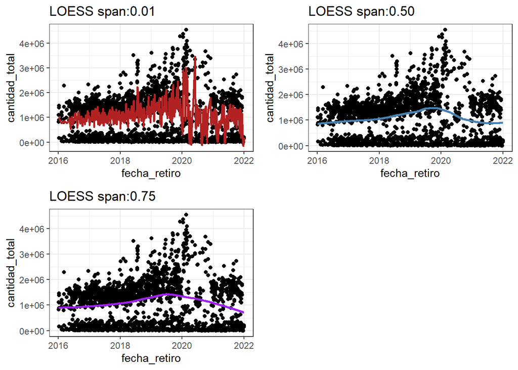

```r
loess=stats::loess(cantidad_total~as.numeric(fecha_retiro), data = rrpp_dia, na.action = 'na.exclude', model = T, span=0.01)
rrpp_dia['loess']=predict(loess,rrpp_dia)
loess_1 = ggplot(rrpp_dia, aes(fecha_retiro,cantidad_total)) + geom_point() + geom_line(aes(y=loess), color='firebrick', size=1) +   labs(title= "LOESS span:0.01") + theme_bw()

loess=stats::loess(cantidad_total~as.numeric(fecha_retiro), data = rrpp_dia, na.action = 'na.exclude', model = T, span=0.5)
rrpp_dia['loess']=predict(loess,rrpp_dia)
loess_2 = ggplot(rrpp_dia, aes(fecha_retiro,cantidad_total)) + geom_point() + geom_line(aes(y=loess), color='steelblue', size=1) +   labs(title= "LOESS span:0.50") + theme_bw()

loess=stats::loess(cantidad_total~as.numeric(fecha_retiro), data = rrpp_dia, na.action = 'na.exclude', model = T, span=0.75)
rrpp_dia['loess']=predict(loess,rrpp_dia)
loess_3 = ggplot(rrpp_dia, aes(fecha_retiro,cantidad_total)) + geom_point() + geom_line(aes(y=loess), color='purple', size=1) +
  labs(title= "LOESS span:0.75") + theme_bw()

cowplot::plot_grid(loess_1, loess_2,loess_3)
```

# 4) Modelo Prophet

Las variables de fecha de retiro y cantidad en kilogramos de residuos se renombran para poder ser cargadas por el modelo. El formato de la variable fecha es el adecuado (YYYY-MM-DD).

```r
#PROPHET DATAFRAME
prophet_df = rrpp_dia %>% select(fecha_retiro, cantidad_total) %>% rename(., ds=fecha_retiro, y=cantidad_total)
```

## 4.1) Entrenamiento

Este primer modelo no cuenta con parámetros adicionales de ajuste.

```r
#PROPHET 1

# Llamamos solo al modelo
prophet_1 = prophet()
# Le pasamos el dataset
prophet_1 = fit.prophet(m = prophet_1, prophet_df)
```

```
## Disabling daily seasonality. Run prophet with daily.seasonality=TRUE to override this.
```

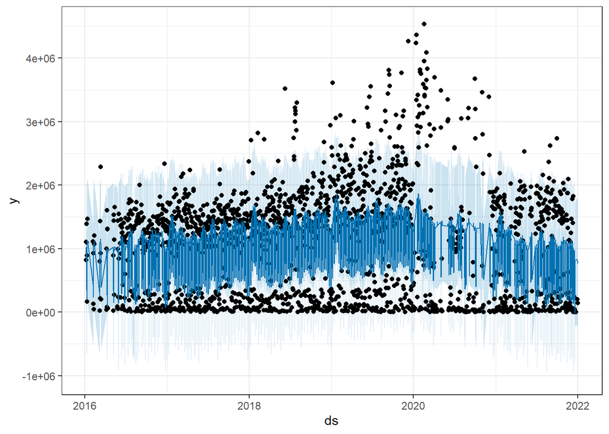

```r
plot(prophet_1,fcst=predict(prophet_1, prophet_df)) +theme_bw()
```

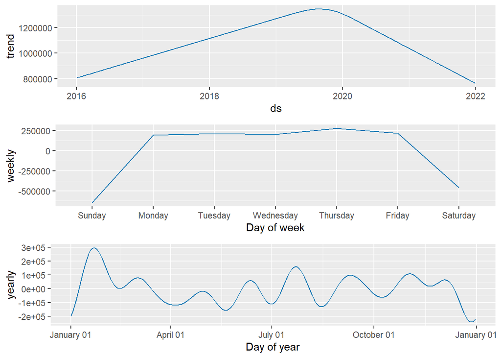

```r
#Componentes del modelo
prophet_plot_components(prophet_1, fcst=predict(prophet_1, prophet_df))
```

En segunda instancia se agregó una variación temporal asociada al mes. Este nuevo elemento del modelo se estima mediante una suma de Fourier de orden 5.

```r
#PROPHET 2

# Llamamos solo al modelo
prophet_2=prophet()
# Agregamos la estacionalidad mensual
prophet_2=add_seasonality(m=prophet_2, name='monthly', period=365/12, fourier.order = 5)

# Le pasamos el dataset
prophet_2 = fit.prophet(m = prophet_2, prophet_df)
```

```
## Disabling daily seasonality. Run prophet with daily.seasonality=TRUE to override this.
```

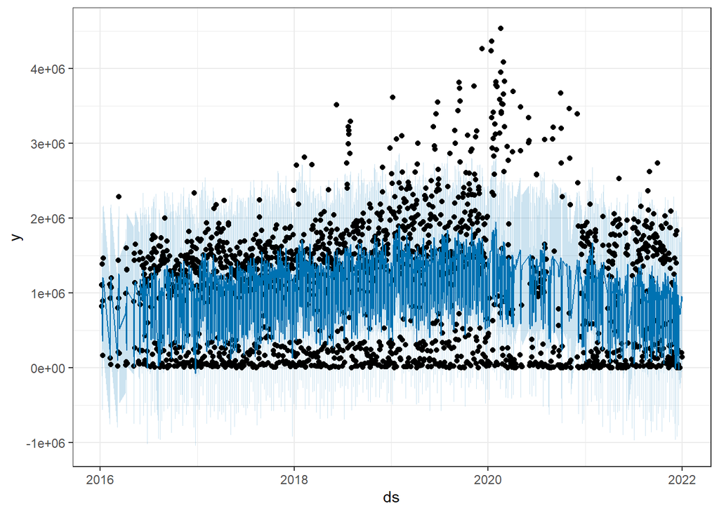

```r
plot(prophet_2,fcst=predict(prophet_2, prophet_df)) +theme_bw()
```

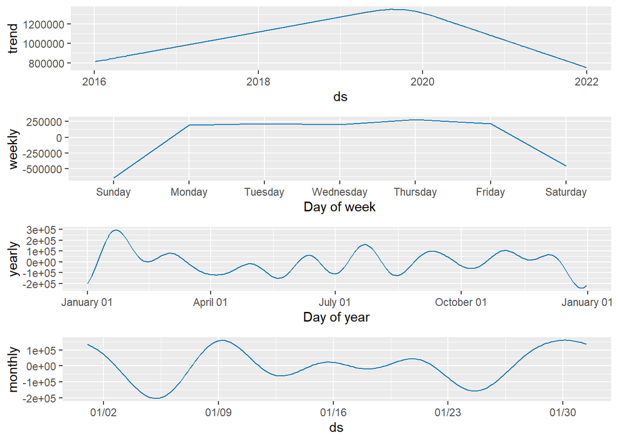

```r
#Componentes del modelo
prophet_plot_components(prophet_2, fcst=predict(prophet_2, prophet_df))
```

```r
#PROPHET 3

#se agrega el periodo de presentación anual de DDJJ
ddjj_rrpp <- function(ds) {
  dates <- as.Date(ds)
  month <- as.numeric(format(dates, '%m'))
  as.numeric((month >= 10  & month <= 12))
}

rrpp_dia$ddjj <- ddjj_rrpp(rrpp_dia$fecha_retiro)

prophet_df = rrpp_dia %>% select(fecha_retiro, cantidad_total, ddjj) %>% rename(., ds=fecha_retiro, y=cantidad_total)

# Llamamos solo al modelo
prophet_3=prophet()
# Agregamos la estacionalidad mensual
prophet_3=add_seasonality(m=prophet_3, name='monthly', period=365/12, fourier.order = 5)

#agregamos un regresor
prophet_3 <- add_regressor(prophet_3, 'ddjj')

# Le pasamos el dataset
prophet_3 = fit.prophet(m = prophet_3, prophet_df)
```

```
## Disabling daily seasonality. Run prophet with daily.seasonality=TRUE to override this.
```

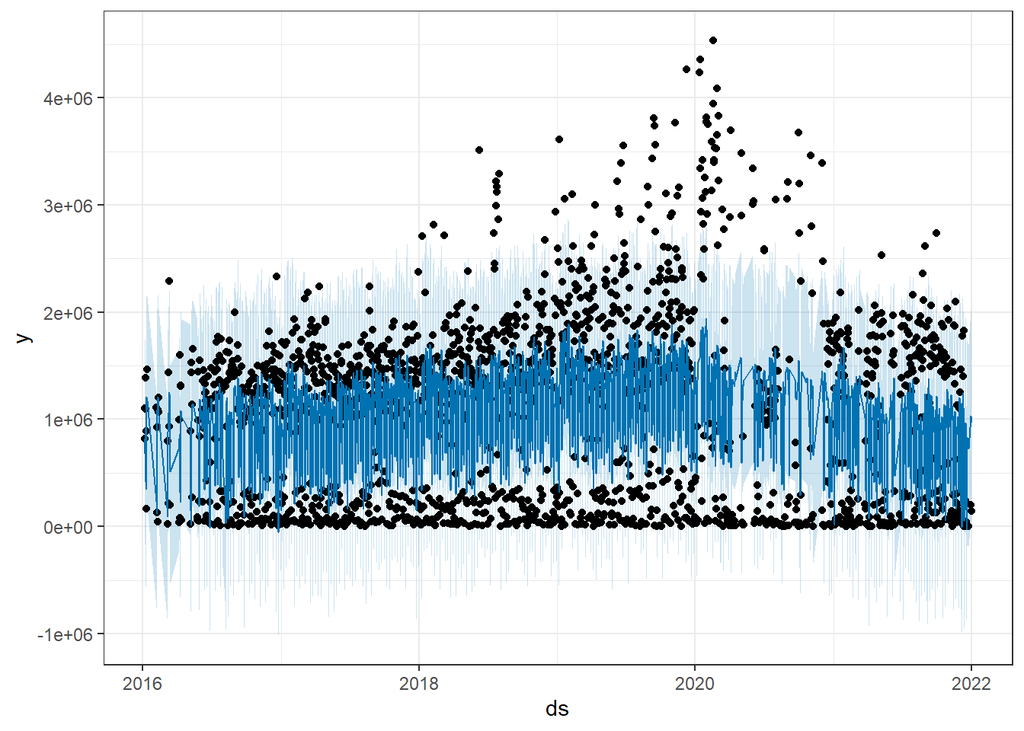

```r
plot(prophet_3,fcst=predict(prophet_3, prophet_df)) +theme_bw()
```

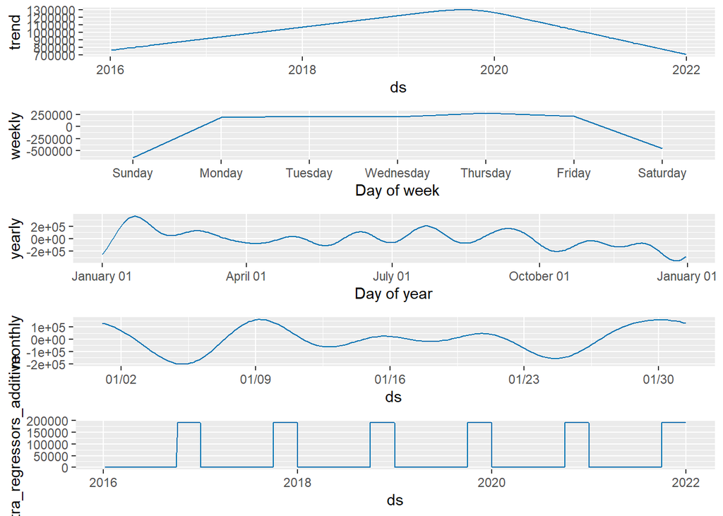

```r
#Componentes del modelo
prophet_plot_components(prophet_3, fcst=predict(prophet_3, prophet_df))
```

Como última alternativa, se agregaron los días festivos de Argentina.

```r
#PROPHET 4

# Llamamos solo al modelo
prophet_4 <- prophet()
# Agregamos la estacionalidad mensual
prophet_4=add_seasonality(m=prophet_4, name='monthly', period=365/12, fourier.order = 5)

#agregamos un regresor
prophet_4 <- add_regressor(prophet_4, 'ddjj')

#agregamos feriados
prophet_4 <- add_country_holidays(prophet_4, country_name = 'AR')


# Le pasamos el dataset
prophet_4 = fit.prophet(m = prophet_4, prophet_df)
```

```
## Disabling daily seasonality. Run prophet with daily.seasonality=TRUE to override this.
```

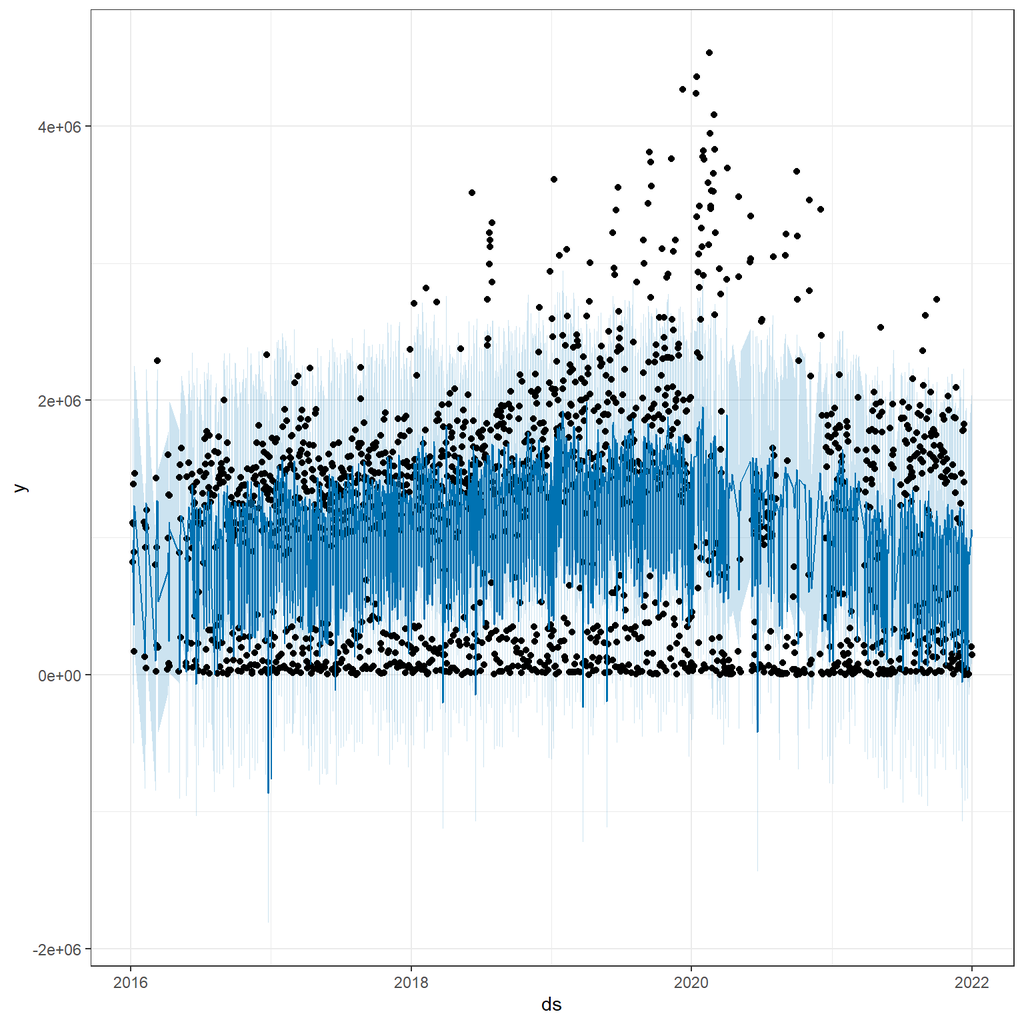

```r
plot(prophet_4,fcst=predict(prophet_4, prophet_df)) +theme_bw()
```

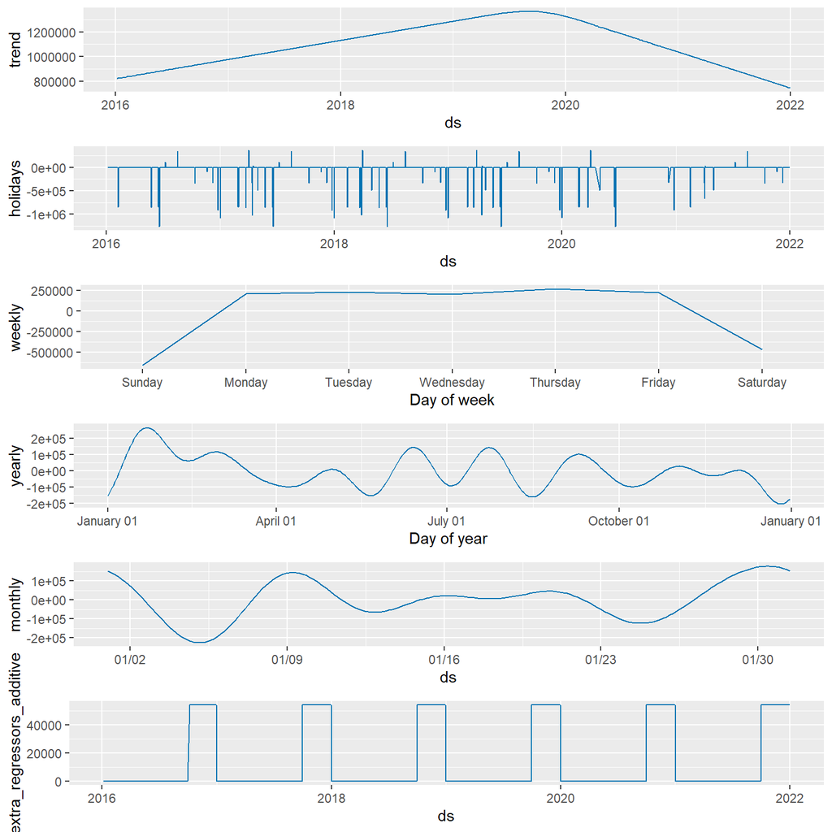

```r
#Componentes del modelo
prophet_plot_components(prophet_4, fcst=predict(prophet_4, prophet_df))
```

## 4.2) Evaluación

La evaluación de los modelos se realizó mediante predicciones históricas simuladas (SHFs, por sus siglas en inglés). Se optó por períodos iniciales de entrenamiento de 60 días, un horizonte de 15 días y desplazaremos la predicción cada 7 días.

```r
#PROPHET 1

cv_1 = cross_validation(prophet_1, initial = 60, period = 7, horizon = 15, units = 'days')
```

```
## Making 291 forecasts with cutoffs between 2016-03-28 and 2021-12-16
```

```
## n.changepoints greater than number of observations. Using 15
```

```
## n.changepoints greater than number of observations. Using 21
## n.changepoints greater than number of observations. Using 21
## n.changepoints greater than number of observations. Using 21
```

```r
#métricas de performance

performance_metrics(cv_1, rolling_window = 0.25)
```

| horizon | mse | rmse | mae | mape | mdape | smape | coverage |
| --- | --- | --- | --- | --- | --- | --- | --- |
| 4 days | 1.052941e+13 | 3244905 | 866231.3 | 42.86586 | 0.7180538 | 0.9328503 | 0.6761409 |
| 5 days | 1.088323e+13 | 3298975 | 924403.9 | 34.79126 | 0.6540481 | 0.9225741 | 0.6526103 |
| 6 days | 1.119385e+13 | 3345722 | 969400.8 | 33.16030 | 0.4439253 | 0.8010506 | 0.6396547 |
| 7 days | 1.161937e+13 | 3408719 | 1002912.3 | 23.14224 | 0.3434303 | 0.6383463 | 0.6445039 |
| 8 days | 1.310923e+13 | 3620667 | 1038976.3 | 25.84944 | 0.3240508 | 0.6289454 | 0.6564096 |
| 9 days | 1.554606e+13 | 3942849 | 1100498.9 | 25.59478 | 0.4233808 | 0.7199979 | 0.6744852 |
| 10 days | 1.811682e+13 | 4256386 | 1169230.5 | 38.66163 | 0.6928590 | 0.9248915 | 0.6759676 |
| 11 days | 2.128259e+13 | 4613306 | 1292306.6 | 47.93139 | 0.7434290 | 0.9616669 | 0.6591946 |
| 12 days | 2.430327e+13 | 4929834 | 1411406.2 | 39.74158 | 0.6807365 | 0.9433453 | 0.6424378 |
| 13 days | 2.450625e+13 | 4950378 | 1468405.0 | 36.09943 | 0.4602850 | 0.8192277 | 0.6359977 |

[output cut: 2 more lines]

```r
#PROPHET 2

cv_2 = cross_validation(prophet_2, initial = 60, period = 7, horizon = 15, units = 'days')
```

```
## Making 291 forecasts with cutoffs between 2016-03-28 and 2021-12-16
```

```
## n.changepoints greater than number of observations. Using 15
```

```
## n.changepoints greater than number of observations. Using 21
## n.changepoints greater than number of observations. Using 21
## n.changepoints greater than number of observations. Using 21
```

```r
#métricas de performance

performance_metrics(cv_2, rolling_window = 0.25)
```

| horizon | mse | rmse | mae | mape | mdape | smape | coverage |
| --- | --- | --- | --- | --- | --- | --- | --- |
| 4 days | 4.434962e+12 | 2105935 | 818998.4 | 41.59995 | 0.7474971 | 0.9365339 | 0.6716104 |
| 5 days | 4.500433e+12 | 2121422 | 871939.5 | 34.76714 | 0.6582660 | 0.9251196 | 0.6624837 |
| 6 days | 4.241525e+12 | 2059496 | 895338.1 | 32.85130 | 0.4349293 | 0.8028969 | 0.6492944 |
| 7 days | 4.166308e+12 | 2041154 | 905306.4 | 22.54326 | 0.3358588 | 0.6404977 | 0.6556258 |
| 8 days | 5.152826e+12 | 2269984 | 926337.5 | 23.14609 | 0.3141819 | 0.6306246 | 0.6577187 |
| 9 days | 7.041634e+12 | 2653608 | 984226.6 | 23.11709 | 0.4189075 | 0.7241165 | 0.6708212 |
| 10 days | 8.662764e+12 | 2943257 | 1045353.6 | 36.87344 | 0.6891261 | 0.9252380 | 0.6723814 |
| 11 days | 9.876255e+12 | 3142651 | 1117787.8 | 46.87201 | 0.7225100 | 0.9602733 | 0.6529364 |
| 12 days | 1.034107e+13 | 3215754 | 1164704.7 | 39.51188 | 0.6909801 | 0.9425351 | 0.6382712 |
| 13 days | 1.158481e+13 | 3403646 | 1213893.9 | 35.40267 | 0.4503183 | 0.8163249 | 0.6321340 |

[output cut: 2 more lines]

```r
#PROPHET 3

cv_3 = cross_validation(prophet_3, initial = 60, period = 7, horizon = 15, units = 'days')
```

```
## Making 291 forecasts with cutoffs between 2016-03-28 and 2021-12-16
```

```
## n.changepoints greater than number of observations. Using 15
```

```
## n.changepoints greater than number of observations. Using 21
## n.changepoints greater than number of observations. Using 21
## n.changepoints greater than number of observations. Using 21
```

```r
#métricas de performance

performance_metrics(cv_3, rolling_window = 0.25)
```

| horizon | mse | rmse | mae | mape | mdape | smape | coverage |
| --- | --- | --- | --- | --- | --- | --- | --- |
| 4 days | 4.436289e+12 | 2106250 | 819840.4 | 41.20825 | 0.7491670 | 0.9390599 | 0.6699570 |
| 5 days | 4.499721e+12 | 2121255 | 871618.7 | 34.52476 | 0.6688531 | 0.9272309 | 0.6604003 |
| 6 days | 4.239699e+12 | 2059053 | 894569.0 | 32.60105 | 0.4387610 | 0.8046531 | 0.6506006 |
| 7 days | 4.165037e+12 | 2040842 | 905372.6 | 22.37737 | 0.3380805 | 0.6414455 | 0.6553502 |
| 8 days | 5.152709e+12 | 2269958 | 927178.4 | 22.85553 | 0.3166427 | 0.6319524 | 0.6571959 |
| 9 days | 7.044006e+12 | 2654055 | 986379.7 | 22.83804 | 0.4194404 | 0.7286952 | 0.6659006 |
| 10 days | 8.665647e+12 | 2943747 | 1047387.3 | 36.34826 | 0.6923605 | 0.9330971 | 0.6655509 |
| 11 days | 9.878854e+12 | 3143064 | 1119907.8 | 46.24449 | 0.7342527 | 0.9685697 | 0.6466864 |
| 12 days | 1.034172e+13 | 3215854 | 1165906.5 | 39.06730 | 0.6924707 | 0.9498003 | 0.6355378 |
| 13 days | 1.158459e+13 | 3403614 | 1215223.3 | 35.01920 | 0.4552078 | 0.8214265 | 0.6321340 |

[output cut: 2 more lines]

```r
#PROPHET 4

cv_4 = cross_validation(prophet_4, initial = 60, period = 7, horizon = 15, units = 'days')
```

```
## Making 291 forecasts with cutoffs between 2016-03-28 and 2021-12-16
```

```
## n.changepoints greater than number of observations. Using 15
```

```
## n.changepoints greater than number of observations. Using 21
## n.changepoints greater than number of observations. Using 21
## n.changepoints greater than number of observations. Using 21
```

```r
#métricas de performance

performance_metrics(cv_4, rolling_window = 0.25)
```

| horizon | mse | rmse | mae | mape | mdape | smape | coverage |
| --- | --- | --- | --- | --- | --- | --- | --- |
| 4 days | 4.557130e+12 | 2134744 | 830273.9 | 42.62164 | 0.7418627 | 0.9482156 | 0.6492725 |
| 5 days | 4.348782e+12 | 2085373 | 869204.4 | 36.01126 | 0.6704053 | 0.9342359 | 0.6300572 |
| 6 days | 4.183967e+12 | 2045475 | 892562.0 | 34.04901 | 0.4480293 | 0.8061041 | 0.6277344 |
| 7 days | 4.551587e+12 | 2133445 | 912544.6 | 22.98927 | 0.3345108 | 0.6433197 | 0.6384687 |
| 8 days | 6.498227e+12 | 2549162 | 967989.7 | 22.67385 | 0.3240750 | 0.6383909 | 0.6407846 |
| 9 days | 9.148899e+12 | 3024715 | 1052278.1 | 22.19606 | 0.4276642 | 0.7405781 | 0.6473654 |
| 10 days | 1.185295e+13 | 3442812 | 1149230.9 | 37.36820 | 0.7009538 | 0.9484982 | 0.6404315 |
| 11 days | 1.408028e+13 | 3752370 | 1240886.1 | 48.22173 | 0.7436909 | 0.9791667 | 0.6255865 |
| 12 days | 1.599443e+13 | 3999303 | 1314426.6 | 41.86230 | 0.7009538 | 0.9581698 | 0.6115027 |
| 13 days | 1.887112e+13 | 4344090 | 1388481.8 | 37.67047 | 0.4805582 | 0.8263269 | 0.6146331 |

[output cut: 2 more lines]

Se grafica la distribución de las métricas de interés para comparar la performance en los distintos horizontes.

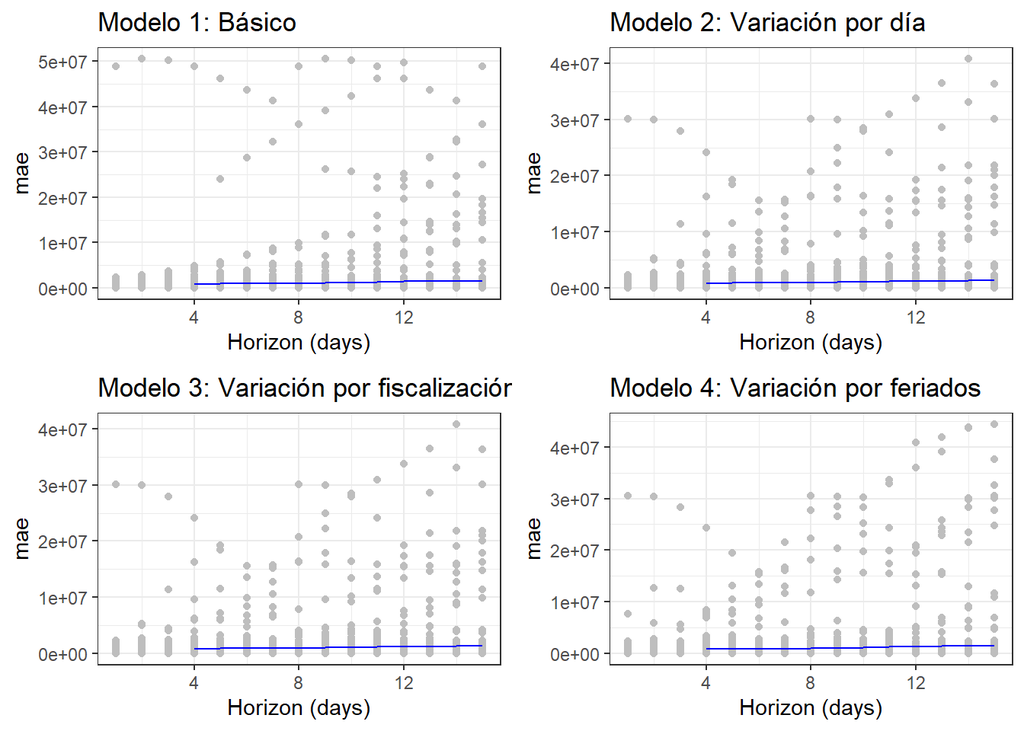

```r
mae_1 = plot_cross_validation_metric(cv_1, metric = 'mae', rolling_window = 0.25) +
            theme_bw() + labs(title="Modelo 1: Básico")
mae_2 = plot_cross_validation_metric(cv_2, metric = 'mae', rolling_window = 0.25) +
           theme_bw() + labs(title="Modelo 2: Variación por día")
mae_3 = plot_cross_validation_metric(cv_3, metric = 'mae', rolling_window = 0.25) +
            theme_bw() + labs(title="Modelo 3: Variación por fiscalización")
mae_4 = plot_cross_validation_metric(cv_4, metric = 'mae', rolling_window = 0.25) +
            theme_bw() + labs(title="Modelo 4: Variación por feriados")
cowplot::plot_grid(mae_1, mae_2, mae_3, mae_4)
```

# 5) Fuentes de consulta

- Documentación de Prophet: https://cran.r-project.org/web/packages/prophet/prophet.pdf
- Documentación de Repositorio de Prophet: https://facebook.github.io/prophet/docs/
- Material didáctico de la asignatura EEA (Esp. en Data Mining-UBA)